# WD STD Analysis

Chao-Sheng, Wu

## Goal

Which items influence WD STD most ?  
How do these items influence WD STD ?

How to manipulate the hardwares such that we can lower WD STD ?

## Say Hello to our Data

Load our data, and have a look !

```r
data <- read.csv("PDS_Join_ItemPL.csv")
data <- as_tibble(data)
data_backup <- as_tibble(data)
datatable(data[1:100,c(1:200,1500:1755)] ,
          fillContainer = T ,
          height = 600, options = list(scrollY = 350))
```

|  | LOT_ID | WFR_ID | DV.CurvatureBubbler_1_Bypass.VALUE | DV.CurvatureBubbler_2_Bypass.VALUE | DV.CurvatureBubbler_4_Bypass.VALUE | DV.CurvatureBubbler_5_Bypass.VALUE | DV.CurvatureBubbler_6_Bypass.VALUE | DV.CurvatureBubbler_8_Bypass.VALUE | DV.CurvatureBubbler_9_Bypass.VALUE | DV.CurvatureBubbler01_BathTemp.VALUE | DV.CurvatureBubbler01_DDMFC.VALUE | DV.CurvatureBubbler01_MFC.VALUE | DV.CurvatureBubbler01_PressureControllerPC90.VALUE | DV.CurvatureBubbler01_PushMFC.VALUE | DV.CurvatureBubbler02_BathTemp.VALUE | DV.CurvatureBubbler02_MFC.VALUE | DV.CurvatureBubbler02_PressureControllerPC90.VALUE | DV.CurvatureBubbler03_BathTemp.VALUE | DV.CurvatureBubbler03_MFC.VALUE | DV.CurvatureBubbler03_PressureControllerPC90.VALUE | DV.CurvatureBubbler04_BathTemp.VALUE | DV.CurvatureBubbler04_MFC.VALUE | DV.CurvatureBubbler04_PressureControllerPC90.VALUE | DV.CurvatureBubbler05_BathTemp.VALUE | DV.CurvatureBubbler05_MFC.VALUE | DV.CurvatureBubbler05_PressureControllerPC90.VALUE | DV.CurvatureBubbler06_BathTemp.VALUE | DV.CurvatureBubbler06_MFC.VALUE | DV.CurvatureBubbler06_PressureControllerPC90.VALUE | … |
| --- | --- | --- | --- | --- | --- | --- | --- | --- | --- | --- | --- | --- | --- | --- | --- | --- | --- | --- | --- | --- | --- | --- | --- | --- | --- | --- | --- | --- | --- | --- |
| 1 | CS90151 | CS901510100 | 3 | 0 | 3 | 3 | 3 | 0 | 0 | 20 | 24.8 | 24.955241 | 899.98372 | 99.8128256 | 20 | 425.992842 | 700.008136 | 20 | 1699.91864 | 700.008136 | 5.003333333 | 11.9775394 | 819.970704 | 5.003333333 | 59.9121092 | 819.98698 | 30 | 60.4329428 | 799.951174 | … |
| 2 | CS90151 | CS901510700 | 3 | 0 | 3 | 3 | 3 | 0 | 0 | 20 | 24.8 | 24.955241 | 899.98372 | 99.8128256 | 20 | 425.992842 | 700.008136 | 20 | 1699.91864 | 700.008136 | 5.003333333 | 11.9775394 | 819.970704 | 5.003333333 | 59.9121092 | 819.98698 | 30 | 60.4329428 | 799.951174 | … |
| 3 | CS90151 | CS901511000 | 3 | 0 | 3 | 3 | 3 | 0 | 0 | 20 | 24.8 | 24.955241 | 899.98372 | 99.8128256 | 20 | 425.992842 | 700.008136 | 20 | 1699.91864 | 700.008136 | 5.003333333 | 11.9775394 | 819.970704 | 5.003333333 | 59.9121092 | 819.98698 | 30 | 60.4329428 | 799.951174 | … |
| 4 | CS90151 | CS901511400 | 3 | 0 | 3 | 3 | 3 | 0 | 0 | 20 | 24.8 | 24.955241 | 899.98372 | 99.8128256 | 20 | 425.992842 | 700.008136 | 20 | 1699.91864 | 700.008136 | 5.003333333 | 11.9775394 | 819.970704 | 5.003333333 | 59.9121092 | 819.98698 | 30 | 60.4329428 | 799.951174 | … |
| 5 | CS90151 | CS901510400 | 3 | 0 | 3 | 3 | 3 | 0 | 0 | 20 | 24.8 | 24.955241 | 899.98372 | 99.8128256 | 20 | 425.992842 | 700.008136 | 20 | 1699.91864 | 700.008136 | 5.003333333 | 11.9775394 | 819.970704 | 5.003333333 | 59.9121092 | 819.98698 | 30 | 60.4329428 | 799.951174 | … |
| 6 | CS90151 | CS901510800 | 3 | 0 | 3 | 3 | 3 | 0 | 0 | 20 | 24.8 | 24.955241 | 899.98372 | 99.8128256 | 20 | 425.992842 | 700.008136 | 20 | 1699.91864 | 700.008136 | 5.003333333 | 11.9775394 | 819.970704 | 5.003333333 | 59.9121092 | 819.98698 | 30 | 60.4329428 | 799.951174 | … |
| 7 | CS90151 | CS901510900 | 3 | 0 | 3 | 3 | 3 | 0 | 0 | 20 | 24.8 | 24.955241 | 899.98372 | 99.8128256 | 20 | 425.992842 | 700.008136 | 20 | 1699.91864 | 700.008136 | 5.003333333 | 11.9775394 | 819.970704 | 5.003333333 | 59.9121092 | 819.98698 | 30 | 60.4329428 | 799.951174 | … |
| 8 | CS90151 | CS901510500 | 3 | 0 | 3 | 3 | 3 | 0 | 0 | 20 | 24.8 | 24.955241 | 899.98372 | 99.8128256 | 20 | 425.992842 | 700.008136 | 20 | 1699.91864 | 700.008136 | 5.003333333 | 11.9775394 | 819.970704 | 5.003333333 | 59.9121092 | 819.98698 | 30 | 60.4329428 | 799.951174 | … |
| 9 | CS90151 | CS901510600 | 3 | 0 | 3 | 3 | 3 | 0 | 0 | 20 | 24.8 | 24.955241 | 899.98372 | 99.8128256 | 20 | 425.992842 | 700.008136 | 20 | 1699.91864 | 700.008136 | 5.003333333 | 11.9775394 | 819.970704 | 5.003333333 | 59.9121092 | 819.98698 | 30 | 60.4329428 | 799.951174 | … |
| 10 | CS90151 | CS901511200 | 3 | 0 | 3 | 3 | 3 | 0 | 0 | 20 | 24.8 | 24.955241 | 899.98372 | 99.8128256 | 20 | 425.992842 | 700.008136 | 20 | 1699.91864 | 700.008136 | 5.003333333 | 11.9775394 | 819.970704 | 5.003333333 | 59.9121092 | 819.98698 | 30 | 60.4329428 | 799.951174 | … |

[output cut: 90 more lines]

The structure of our columns :
$$\begin{matrix}
\text{LOT_ID} & \text{WFR_ID} &
\{ \; Layer_lItem_i \; \mid for \; 1 \leq l \leq L \; , \; 1 \leq i \leq I_l \; \} &
\text{Position_dummy} & \text{X.PL.WD.STD} & \text{X.PL.WD.AVG}
\end{matrix}$$

How large is our data ?

```r
dim(data)
```

```
[1]  781 1755
```

## Preprocess

#### Delete variables which did not involve into reactor chamber

```r
# find all layer names
item_name <- names(data) ;
layer_name_need_pro <- grep("RealTemp_Outer_WaferTemp", item_name, value = TRUE )
layer_name <- sub("RealTemp_Outer_WaferTemp.*$", "", layer_name_need_pro )
length_ln <- length(layer_name)
# save the names of closed valves
num_cv <- 1
valve_closed <- list()
for ( i in 1:length_ln ) {


  ###########################################################################
  #                                  Bubbler                                #
  ###########################################################################

  ## should replace . by \\. in layer_name, but the result is identical ( e.g. DV.Q3.well )
  pattern_find_Bypass <- paste( "^" , layer_name[i] , "Bubbler_._Bypass.*" , sep = "" )

  item_name_Bypass <- grep( pattern_find_Bypass , item_name , value = TRUE )

  length_item_Bypass <- length( item_name_Bypass )


  ## Note : since 3_Bypass was not recorded, just delete them to simpify analysis

  ## Delete Bubbler03 items
  pattern_delete_Bubbler03 <- paste( layer_name[i] , "Bubbler03" , sep = "" )
  ## item with words : Bubbler03
  item_delete_Bubbler03 <- grep( pattern_delete_Bubbler03 , item_name , value = TRUE )
  data[ , item_delete_Bubbler03 ] <- NULL


  ## find number after Bubbler >> want { 1 2 4 5 6 8 9 } : the numbers are assuming unknown
  ## also the corresponding mean of the *_Bypass respectivly
  ## and delete Bubbler0* items with *_Bypass mean > 2
  for ( j in 1:length_item_Bypass ) {
    Bypass_j <- item_name_Bypass[j]

    number_Bypass_j <- Bypass_j %>%
                          str_extract("_[0-9]_") %>%
                          str_extract("[0-9]")

    values_Bypass <- data[ , Bypass_j ]
    value <- mean(values_Bypass[[1]])

    if ( value > 2 ){

      ## find items with Bubbler0j and delete all
      pattern_delete_Bubbler0j <- paste( layer_name[i] , "Bubbler0" , number_Bypass_j , ".*" , sep = "" )
      item_delete_Bubbler0j <- grep( pattern_delete_Bubbler0j , item_name , value = TRUE )

      data[ , item_delete_Bubbler0j ] <- NULL

      data[ , Bypass_j ] <- NULL  ## valve's value should not influence WD STD

      ##### save name of closed valves
      valve_closed[[num_cv]] <- Bypass_j
      num_cv <- num_cv + 1;
    }
    else {
      data[ , Bypass_j ] <- NULL
    }

  }


  ###########################################################################
  ###########################################################################
  ###########################################################################
  ###########################################################################
  #                                  SiH403                                 #
  ###########################################################################

  pattern_find_Gas <- paste( layer_name[i] , "Gas_3" , sep = "")
  item_Gas <- grep( pattern_find_Gas , item_name , value = TRUE )
  values_Valve_SiH403 <-  data[ , item_Gas ]
  value_Valve_SiH403 <- mean(values_Valve_SiH403[[1]])

  if ( value_Valve_SiH403 < 1 ){
    pattern_delete_SiH403 <- paste( layer_name[i] , "SiH403" , sep = "" )
    item_delete_SiH403 <- grep( pattern_delete_SiH403 , item_name , value = TRUE )
    data[ , item_delete_SiH403 ] <- NULL
    data[ , item_Gas ] <- NULL

    #### save name of closed valve
    valve_closed[[num_cv]] <- item_Gas
    num_cv <- num_cv + 1;
  }

  else{
    data[ , item_Gas ] <- NULL

    ####### combime MFC, DDMFC, PushMFC
    ## find the three columns for each layer
    pattern_MFC <- paste("^" , layer_name[i] , "SiH403_MFC.*" , sep="") ;
    pattern_Push <- paste("^" , layer_name[i] , "SiH403_PushMFC.*" , sep="") ;
    pattern_DD <- paste("^" , layer_name[i] , "SiH403_DDMFC.*" , sep="") ;

    item_name_MFC <- grep( pattern_MFC , item_name , value=TRUE ) ;
    item_name_Push <- grep( pattern_Push , item_name , value=TRUE ) ;
    item_name_DD <- grep( pattern_DD , item_name , value=TRUE ) ;

    Si_MFC <- data[,item_name_MFC] ;
    Si_Push <- data[,item_name_Push] ;
    Si_DD <- data[,item_name_DD] ;

    Si_Mixed <- ( Si_MFC*Si_DD ) / ( Si_MFC + Si_Push ) ;
    ## Add column
    column_name_add <- paste( layer_name[i] , 'SiH403_Mixed' , sep="") ;
    data[column_name_add] <- Si_Mixed ;
    #add_column(data, column_name_add = Si_Mixed, .before = Position_dummy)
    ## Delete the three columns
    data[ , c( item_name_MFC , item_name_Push , item_name_DD ) ] <- NULL ;

  }


}
```

Which variables were eliminated ?

```
[1] "DV.CurvatureBubbler_1_Bypass.VALUE"
[1] "DV.CurvatureBubbler_4_Bypass.VALUE"
[1] "DV.CurvatureBubbler_5_Bypass.VALUE"
[1] "DV.CurvatureBubbler_6_Bypass.VALUE"
[1] "DV.H6.Barrier1Bubbler_1_Bypass.VALUE"
[1] "DV.H6.Barrier1Bubbler_4_Bypass.VALUE"
[1] "DV.H6.Barrier1Bubbler_5_Bypass.VALUE"
[1] "DV.H6.Barrier1Bubbler_6_Bypass.VALUE"
[1] "DV.H6.Barrier1Bubbler_8_Bypass.VALUE"
[1] "DV.H6.Barrier1Bubbler_9_Bypass.VALUE"
[1] "DV.H6.Barrier1WBubbler_1_Bypass.VALUE"
[1] "DV.H6.Barrier1WBubbler_4_Bypass.VALUE"
[1] "DV.H6.Barrier1WBubbler_5_Bypass.VALUE"
[1] "DV.H6.Barrier1WBubbler_6_Bypass.VALUE"
[1] "DV.H6.Barrier2Bubbler_1_Bypass.VALUE"
```

[output cut: 169 more lines]

How large is our data now ?

```
[1] 781 696
```

#### Missing Data

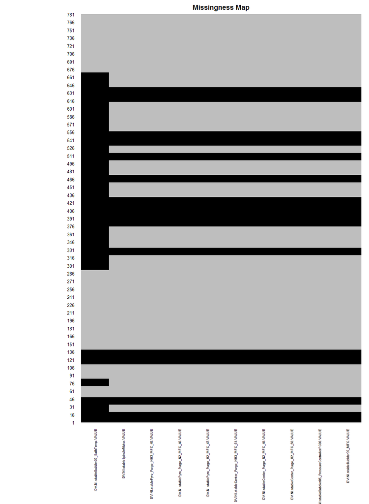

The size of our data

```
[1] 781 686
```

#### Near-zero-variance Variables

|  | DV.CurvatureBubbler02_BathTemp.VALUE | DV.CurvatureCenter_Purge_H2_MFC_50.VALUE | DV.CurvaturePyro_Purge_H2_MFC_47.VALUE | DV.H6.Barrier1Center_Purge_H2_MFC_50.VALUE | DV.H6.Barrier1Pyro_Purge_H2_MFC_47.VALUE | DV.H6.Barrier1WBubbler02_BathTemp.VALUE | DV.H6.Barrier1WCenter_Purge_H2_MFC_50.VALUE | DV.H6.Barrier1WPyro_Purge_H2_MFC_47.VALUE | DV.H6.Barrier2Center_Purge_H2_MFC_50.VALUE | DV.H6.Barrier2Pyro_Purge_H2_MFC_47.VALUE | DV.H6.Barrier2WBubbler02_BathTemp.VALUE | DV.H6.Barrier2WCenter_Purge_H2_MFC_50.VALUE | DV.H6.Barrier2WPyro_Purge_H2_MFC_47.VALUE | DV.H6.Barrier3Center_Purge_H2_MFC_50.VALUE | DV.H6.Barrier3Pyro_Purge_H2_MFC_47.VALUE | DV.H6.Barrier3WBubbler02_BathTemp.VALUE | DV.H6.Barrier3WCenter_Purge_H2_MFC_50.VALUE | DV.H6.Barrier3WPyro_Purge_H2_MFC_47.VALUE | DV.H6.Barrier4Center_Purge_H2_MFC_50.VALUE | DV.H6.Barrier4Pyro_Purge_H2_MFC_47.VALUE | DV.H6.Barrier4WBubbler02_BathTemp.VALUE | DV.H6.Barrier4WCenter_Purge_H2_MFC_50.VALUE | DV.H6.Barrier4WPyro_Purge_H2_MFC_47.VALUE | DV.H6.Barrier5Center_Purge_H2_MFC_50.VALUE | DV.H6.Barrier5Pyro_Purge_H2_MFC_47.VALUE | DV.H6.Barrier5WBubbler02_BathTemp.VALUE | DV.H6.Barrier5WCenter_Purge_H2_MFC_50.VALUE | DV.H6.Barrier5WPyro_Purge_H2_MFC_47.VALUE | DV.H6.Barrier6Center_Purge_H2_MFC_50.VALUE | … |
| --- | --- | --- | --- | --- | --- | --- | --- | --- | --- | --- | --- | --- | --- | --- | --- | --- | --- | --- | --- | --- | --- | --- | --- | --- | --- | --- | --- | --- | --- | --- |
| 1 | 20 | 0 | 0 | 0 | 0 | 20 | 0 | 0 | 0 | 0 | 20 | 0 | 0 | 0 | 0 | 20 | 0 | 0 | 0 | 0 | 20 | 0 | 0 | 0 | 0 | 20 | 0 | 0 | 0 | … |
| 2 | 20 | 0 | 0 | 0 | 0 | 20 | 0 | 0 | 0 | 0 | 20 | 0 | 0 | 0 | 0 | 20 | 0 | 0 | 0 | 0 | 20 | 0 | 0 | 0 | 0 | 20 | 0 | 0 | 0 | … |
| 3 | 20 | 0 | 0 | 0 | 0 | 20 | 0 | 0 | 0 | 0 | 20 | 0 | 0 | 0 | 0 | 20 | 0 | 0 | 0 | 0 | 20 | 0 | 0 | 0 | 0 | 20 | 0 | 0 | 0 | … |
| 4 | 20 | 0 | 0 | 0 | 0 | 20 | 0 | 0 | 0 | 0 | 20 | 0 | 0 | 0 | 0 | 20 | 0 | 0 | 0 | 0 | 20 | 0 | 0 | 0 | 0 | 20 | 0 | 0 | 0 | … |
| 5 | 20 | 0 | 0 | 0 | 0 | 20 | 0 | 0 | 0 | 0 | 20 | 0 | 0 | 0 | 0 | 20 | 0 | 0 | 0 | 0 | 20 | 0 | 0 | 0 | 0 | 20 | 0 | 0 | 0 | … |
| 6 | 20 | 0 | 0 | 0 | 0 | 20 | 0 | 0 | 0 | 0 | 20 | 0 | 0 | 0 | 0 | 20 | 0 | 0 | 0 | 0 | 20 | 0 | 0 | 0 | 0 | 20 | 0 | 0 | 0 | … |
| 7 | 20 | 0 | 0 | 0 | 0 | 20 | 0 | 0 | 0 | 0 | 20 | 0 | 0 | 0 | 0 | 20 | 0 | 0 | 0 | 0 | 20 | 0 | 0 | 0 | 0 | 20 | 0 | 0 | 0 | … |
| 8 | 20 | 0 | 0 | 0 | 0 | 20 | 0 | 0 | 0 | 0 | 20 | 0 | 0 | 0 | 0 | 20 | 0 | 0 | 0 | 0 | 20 | 0 | 0 | 0 | 0 | 20 | 0 | 0 | 0 | … |
| 9 | 20 | 0 | 0 | 0 | 0 | 20 | 0 | 0 | 0 | 0 | 20 | 0 | 0 | 0 | 0 | 20 | 0 | 0 | 0 | 0 | 20 | 0 | 0 | 0 | 0 | 20 | 0 | 0 | 0 | … |
| 10 | 20 | 0 | 0 | 0 | 0 | 20 | 0 | 0 | 0 | 0 | 20 | 0 | 0 | 0 | 0 | 20 | 0 | 0 | 0 | 0 | 20 | 0 | 0 | 0 | 0 | 20 | 0 | 0 | 0 | … |

[output cut: 771 more lines]

The size of our data

```
[1] 781 608
```

#### Pseudo-replication

|  | LOT_ID | WFR_ID | DV.CurvatureBubbler02_MFC.VALUE | DV.CurvatureBubbler02_PressureControllerPC90.VALUE | DV.CurvatureBubbler08_BathTemp.VALUE | DV.CurvatureBubbler08_MFC.VALUE | DV.CurvatureBubbler08_PressureControllerPC90.VALUE | DV.CurvatureBubbler09_BathTemp.VALUE | DV.CurvatureBubbler09_MFC.VALUE | DV.CurvatureBubbler09_PressureControllerPC90.VALUE | DV.CurvatureButterflyGateVale_position.VALUE | DV.CurvatureCenter_Purge_N2_MFC_49.VALUE | DV.CurvatureCenter_Purge_NH3_MFC_51.VALUE | DV.CurvaturePyro_Purge_N2_MFC_46.VALUE | DV.CurvaturePyro_Purge_NH3_MFC_48.VALUE | DV.CurvatureRealTemp_Inner_WaferTemp.VALUE | DV.CurvatureRealTemp_Middle_WaferTemp.VALUE | DV.CurvatureRealTemp_Outer_WaferTemp.VALUE | DV.CurvatureRTCarrierRotationSpeed.VALUE | DV.CurvatureSiH403_PC.VALUE | DV.CurvatureSpindleMotor.VALUE | DV.H6.Barrier1Bubbler02_BathTemp.VALUE | DV.H6.Barrier1Bubbler02_MFC.VALUE | DV.H6.Barrier1Bubbler02_PressureControllerPC90.VALUE | DV.H6.Barrier1ButterflyGateVale_position.VALUE | DV.H6.Barrier1Center_Purge_N2_MFC_49.VALUE | DV.H6.Barrier1Center_Purge_NH3_MFC_51.VALUE | DV.H6.Barrier1Pyro_Purge_N2_MFC_46.VALUE | DV.H6.Barrier1Pyro_Purge_NH3_MFC_48.VALUE | … |
| --- | --- | --- | --- | --- | --- | --- | --- | --- | --- | --- | --- | --- | --- | --- | --- | --- | --- | --- | --- | --- | --- | --- | --- | --- | --- | --- | --- | --- | --- | --- |
| 1 | CS90151 | CS901510100 | 425.992842 | 700.008136 | 25.01 | 621.956378 | 699.967446 | 25.01 | 649.951168 | 699.967446 | 29.41651355 | 98.2381186 | 81.8750004 | 4.9574 | 4.13004558 | 825.0636364 | 823.2454545 | 825.0545455 | 499.7045455 | 799.96745 | 500.0208 | 20 | 425.9826788 | 699.9922861 | 29.91520847 | 98.23571117 | 81.87577585 | 4.95713089 | 4.129406489 | … |
| 2 | CS90151 | CS901510700 | 425.992842 | 700.008136 | 25.01 | 621.956378 | 699.967446 | 25.01 | 649.951168 | 699.967446 | 29.41651355 | 98.2381186 | 81.8750004 | 4.9574 | 4.13004558 | 825.0636364 | 823.2454545 | 825.0545455 | 499.7045455 | 799.96745 | 500.0208 | 20 | 425.9826788 | 699.9922861 | 29.91520847 | 98.23571117 | 81.87577585 | 4.95713089 | 4.129406489 | … |
| 3 | CS90151 | CS901511000 | 425.992842 | 700.008136 | 25.01 | 621.956378 | 699.967446 | 25.01 | 649.951168 | 699.967446 | 29.41651355 | 98.2381186 | 81.8750004 | 4.9574 | 4.13004558 | 825.0636364 | 823.2454545 | 825.0545455 | 499.7045455 | 799.96745 | 500.0208 | 20 | 425.9826788 | 699.9922861 | 29.91520847 | 98.23571117 | 81.87577585 | 4.95713089 | 4.129406489 | … |
| 4 | CS90151 | CS901511400 | 425.992842 | 700.008136 | 25.01 | 621.956378 | 699.967446 | 25.01 | 649.951168 | 699.967446 | 29.41651355 | 98.2381186 | 81.8750004 | 4.9574 | 4.13004558 | 825.0636364 | 823.2454545 | 825.0545455 | 499.7045455 | 799.96745 | 500.0208 | 20 | 425.9826788 | 699.9922861 | 29.91520847 | 98.23571117 | 81.87577585 | 4.95713089 | 4.129406489 | … |
| 5 | CS90151 | CS901510400 | 425.992842 | 700.008136 | 25.01 | 621.956378 | 699.967446 | 25.01 | 649.951168 | 699.967446 | 29.41651355 | 98.2381186 | 81.8750004 | 4.9574 | 4.13004558 | 825.0636364 | 823.2454545 | 825.0545455 | 499.7045455 | 799.96745 | 500.0208 | 20 | 425.9826788 | 699.9922861 | 29.91520847 | 98.23571117 | 81.87577585 | 4.95713089 | 4.129406489 | … |
| 6 | CS90151 | CS901510800 | 425.992842 | 700.008136 | 25.01 | 621.956378 | 699.967446 | 25.01 | 649.951168 | 699.967446 | 29.41651355 | 98.2381186 | 81.8750004 | 4.9574 | 4.13004558 | 825.0636364 | 823.2454545 | 825.0545455 | 499.7045455 | 799.96745 | 500.0208 | 20 | 425.9826788 | 699.9922861 | 29.91520847 | 98.23571117 | 81.87577585 | 4.95713089 | 4.129406489 | … |
| 7 | CS90151 | CS901510900 | 425.992842 | 700.008136 | 25.01 | 621.956378 | 699.967446 | 25.01 | 649.951168 | 699.967446 | 29.41651355 | 98.2381186 | 81.8750004 | 4.9574 | 4.13004558 | 825.0636364 | 823.2454545 | 825.0545455 | 499.7045455 | 799.96745 | 500.0208 | 20 | 425.9826788 | 699.9922861 | 29.91520847 | 98.23571117 | 81.87577585 | 4.95713089 | 4.129406489 | … |
| 8 | CS90151 | CS901510500 | 425.992842 | 700.008136 | 25.01 | 621.956378 | 699.967446 | 25.01 | 649.951168 | 699.967446 | 29.41651355 | 98.2381186 | 81.8750004 | 4.9574 | 4.13004558 | 825.0636364 | 823.2454545 | 825.0545455 | 499.7045455 | 799.96745 | 500.0208 | 20 | 425.9826788 | 699.9922861 | 29.91520847 | 98.23571117 | 81.87577585 | 4.95713089 | 4.129406489 | … |
| 9 | CS90151 | CS901510600 | 425.992842 | 700.008136 | 25.01 | 621.956378 | 699.967446 | 25.01 | 649.951168 | 699.967446 | 29.41651355 | 98.2381186 | 81.8750004 | 4.9574 | 4.13004558 | 825.0636364 | 823.2454545 | 825.0545455 | 499.7045455 | 799.96745 | 500.0208 | 20 | 425.9826788 | 699.9922861 | 29.91520847 | 98.23571117 | 81.87577585 | 4.95713089 | 4.129406489 | … |
| 10 | CS90151 | CS901511200 | 425.992842 | 700.008136 | 25.01 | 621.956378 | 699.967446 | 25.01 | 649.951168 | 699.967446 | 29.41651355 | 98.2381186 | 81.8750004 | 4.9574 | 4.13004558 | 825.0636364 | 823.2454545 | 825.0545455 | 499.7045455 | 799.96745 | 500.0208 | 20 | 425.9826788 | 699.9922861 | 29.91520847 | 98.23571117 | 81.87577585 | 4.95713089 | 4.129406489 | … |

[output cut: 4 more lines]

To average the replications is a reasonable way.

```r
movetolast <- function(data, move) {
  data[c(setdiff(names(data), move), move)]
}
## the data is refer to the data after "Abnormal Data Checking.R"
data_need_avg_pre <- data ;
#may do some preprocess
data_need_avg <- data_need_avg_pre ;
all_levels <- levels(data_need_avg$LOT_ID) ;
length_levels <- length(all_levels) ;
Results_hm <- data.frame() ;
data_avg <- data_need_avg %>%
                  select( -"WFR_ID",-"Position_dummy",-"X.PL.WD.AVG" )  %>%
                  movetolast("X.PL.WD.STD") %>%
                  group_by(LOT_ID) %>%
                  summarize_all( mean , na.rm=TRUE )
```

```
[1]  58 605
```

#### Data Normalization

```r
data_normalization_hm <- data_avg  %>%
                          select(-"LOT_ID" , -"X.PL.WD.STD")  %>%
                          scale(center = FALSE , scale = FALSE)
data_normalization_hm <- cbind.data.frame( data_avg[,"LOT_ID"] ,
                                           data_normalization_hm ,
                                           data_avg[,"X.PL.WD.STD"] )
```

#### Multicollinearity Test

Correlation for each layer

```r
for ( i in 1:length(layer_name) ) {
  ## need to avoiding find ?W in W pattern
  A <- grep(layer_name[i] , names(data_normalization_hm) ,  value=TRUE)
  B <- grep( paste(layer_name[i],"W",sep="") , names(data_normalization_hm) ,  value=TRUE)
  temp_name <- setdiff(A,B)

  cor_layer <- cor(data_normalization_hm[,c(temp_name,"X.PL.WD.STD")],
                   use="pairwise.complete.obs")

  cor_sorted <- as.matrix(sort(cor_layer[,'X.PL.WD.STD'], decreasing = TRUE))
  #select only high corelations
  CorHigh <- names(which(apply(cor_sorted, 1, function(x) abs(x)>0.1)))
  cor_layer <- cor_layer[CorHigh, CorHigh]


  corrplot.mixed(cor_layer,
                 tl.col="black",
                 tl.pos = "lt" ,
                 tl.cex = 0.63
                 )


}
rm(temp_name,cor_layer,cor_sorted,CorHigh,A,B)
```

[output not shown]

Take off one of the two items with correlation = 1

```r
for ( i in 1:length(layer_name) ){

  temp_name <- paste( layer_name[i] , "Bubbler09_BathTemp.VALUE" , sep= "")

  temp_name2 <- paste( layer_name[i] , "Bubbler01_BathTemp.VALUE" , sep= "")

  data_normalization_hm[,temp_name] <- NULL

  data_normalization_hm[,temp_name2] <- NULL


}
rm(temp_name)
```

Test more formally

```r
for ( i in 22:24 ){
  A <- grep(layer_name[i] , names(data_normalization_hm) ,  value=TRUE)
  B <- grep( paste(layer_name[i],"W",sep="") , names(data_normalization_hm) ,  value=TRUE)
  temp_name <- setdiff(A,B)

  temp_data <- data_normalization_hm[,c(temp_name,"X.PL.WD.STD")]


  model <- lm(X.PL.WD.STD ~. , data=temp_data)
  print(colldiag(model))
}
rm(A,B,temp_name,temp_data,model)
```

[output not shown]

Summary of the above test :

- DV.Nitridaton : ButterflyGateVale_position , Center_Purge_N2_MFC_49 , Center_Purge_NH3_MFC_51 三個item高度線性相關
- DV.Nucl.Temp.Stable : Center_Purge_N2_MFC_49 , Pyro_Purge_H2_MFC_47 高度線性相關
- DV.Nucl.Temp.Stable : Center_Purge_NH3_MFC_51 , Pyro_Purge_N2_MFC_46 , Pyro_Purge_NH3_MFC_48 高度線性相關
- DV.Q2.Barrier1 : Bubbler02_MFC , RealTemp_Inner_WaferTemp , RealTemp_Outer_WaferTemp 線性相關
- DV.Q2.Barrier2 : Bubbler01_DDMFC , Bubbler02_MFC 輕度線性相關
- DV.Q2.Barrier3 : Bubbler02_MFC , Bubbler09_MFC , Center_Purge_N2_MFC_49高度線性相關
- DV.Q2.pre.cap : Bubbler02_MFC , Bubbler08_PressureControllerPC90線性相關
- DV.Q2.well : Bubbler02_MFC , Pyro_Purge_NH3_MFC_48線性相關
- DV.Q3.Barrier1 : Bubbler02_MFC , Pyro_Purge_NH3_MFC_48線性相關
- DV.Q3.Barrier2 : Bubbler02_MFC , Pyro_Purge_NH3_MFC_48 線性相關
- DV.Q3.Barrier3 : Bubbler02_MFC , Bubbler09_MFC , Center_Purge_N2_MFC_49高度線性相關
- DV.Q3.cap : Bubbler02_MFC , Pyro_Purge_NH3_MFC_48線性相關
- DV.Q3.pre.cap : Bubbler02_MFC , Bubbler08_PressureControllerPC90線性相關
- DV.Q3.pre.cap : Bubbler09_MFC , Bubbler09_PressureControllerPC90輕度線性相關
- DV.Q3.well : Bubbler02_MFC , Pyro_Purge_NH3_MFC_48線性相關

Generally speaking, take out 1 item of each multicollinear relationship.

## It’s Time to Model !!!

Seperate our data into training and test set

```r
library(ISLR) ;
library(glmnet) ;
library(dplyr) ;
library(tidyr) ;
row.names(data_normalization_hm) <- data_normalization_hm$LOT_ID
data_normalization_hm[,"LOT_ID"] <- NULL
X <- model.matrix(X.PL.WD.STD ~ ., data = data_normalization_hm)[,-1]
y <- data_normalization_hm$X.PL.WD.STD ;
set.seed(2) ;
train =  data_normalization_hm %>%
  sample_frac(0.6) ;
test = data_normalization_hm %>%
  setdiff(train) ;
x_train = model.matrix(X.PL.WD.STD~., train)[,-1]
x_test = model.matrix(X.PL.WD.STD~., test)[,-1]
y_train = train %>%
  select(X.PL.WD.STD)  %>%
  unlist() %>%
  as.numeric()
y_test = test %>%
  select(X.PL.WD.STD)  %>%
  unlist() %>%
  as.numeric()
```

How to choose a suitable model for the problem ?

We may try the most parsimornious model first.

#### Least Sqaures Regression

```r
Least.Squares_mod <- lm(X.PL.WD.STD~. ,data=train)
```

Summary of our model

```r
summary(Least.Squares_mod)
```

```
Call:
lm(formula = X.PL.WD.STD ~ ., data = train)

Residuals:
ALL 35 residuals are 0: no residual degrees of freedom!

Coefficients: (569 not defined because of singularities)
                                                            Estimate Std. Error t value Pr(>|t|)
(Intercept)                                               -1.976e+05         NA      NA       NA
DV.CurvatureBubbler02_MFC.VALUE                            4.749e+00         NA      NA       NA
DV.CurvatureBubbler02_PressureControllerPC90.VALUE        -8.377e+00         NA      NA       NA
DV.CurvatureBubbler08_BathTemp.VALUE                       4.275e+01         NA      NA       NA
DV.CurvatureBubbler08_MFC.VALUE                           -4.709e+01         NA      NA       NA
DV.CurvatureBubbler08_PressureControllerPC90.VALUE         2.981e+01         NA      NA       NA
DV.CurvatureBubbler09_BathTemp.VALUE                              NA         NA      NA       NA
DV.CurvatureBubbler09_MFC.VALUE                            3.513e+01         NA      NA       NA
DV.CurvatureBubbler09_PressureControllerPC90.VALUE        -4.536e+01         NA      NA       NA
DV.CurvatureButterflyGateVale_position.VALUE               2.864e+00         NA      NA       NA
DV.CurvatureCenter_Purge_N2_MFC_49.VALUE                  -5.659e+01         NA      NA       NA
DV.CurvatureCenter_Purge_NH3_MFC_51.VALUE                 -2.815e+01         NA      NA       NA
DV.CurvaturePyro_Purge_N2_MFC_46.VALUE                    -5.823e+01         NA      NA       NA
DV.CurvaturePyro_Purge_NH3_MFC_48.VALUE                   -3.419e+02         NA      NA       NA
DV.CurvatureRealTemp_Inner_WaferTemp.VALUE                -6.132e+00         NA      NA       NA
DV.CurvatureRealTemp_Middle_WaferTemp.VALUE               -2.452e-01         NA      NA       NA
DV.CurvatureRealTemp_Outer_WaferTemp.VALUE                 4.799e-01         NA      NA       NA
DV.CurvatureRTCarrierRotationSpeed.VALUE                  -4.141e+00         NA      NA       NA
DV.CurvatureSiH403_PC.VALUE                               -1.246e+01         NA      NA       NA
DV.CurvatureSpindleMotor.VALUE                             6.458e-01         NA      NA       NA
DV.H6.Barrier1Bubbler02_BathTemp.VALUE                    -5.662e+02         NA      NA       NA
DV.H6.Barrier1Bubbler02_MFC.VALUE                          4.418e+01         NA      NA       NA
DV.H6.Barrier1Bubbler02_PressureControllerPC90.VALUE       3.998e+02         NA      NA       NA
DV.H6.Barrier1ButterflyGateVale_position.VALUE            -3.323e+00         NA      NA       NA
DV.H6.Barrier1Center_Purge_N2_MFC_49.VALUE                 7.619e+01         NA      NA       NA
DV.H6.Barrier1Center_Purge_NH3_MFC_51.VALUE                9.645e+01         NA      NA       NA
DV.H6.Barrier1Pyro_Purge_N2_MFC_46.VALUE                   6.091e+02         NA      NA       NA
DV.H6.Barrier1Pyro_Purge_NH3_MFC_48.VALUE                  6.691e+02         NA      NA       NA
DV.H6.Barrier1RealTemp_Inner_WaferTemp.VALUE               1.516e+01         NA      NA       NA
DV.H6.Barrier1RealTemp_Middle_WaferTemp.VALUE             -6.464e-01         NA      NA       NA
DV.H6.Barrier1RealTemp_Outer_WaferTemp.VALUE              -2.352e-01         NA      NA       NA
DV.H6.Barrier1RTCarrierRotationSpeed.VALUE                 9.582e+00         NA      NA       NA
```

[output cut: 208 more lines]

```
DV.H6.well2Bubbler08_MFC.VALUE                                    NA         NA      NA       NA
DV.H6.well2Bubbler08_PressureControllerPC90.VALUE                 NA         NA      NA       NA
DV.H6.well2Bubbler09_BathTemp.VALUE                               NA         NA      NA       NA
DV.H6.well2Bubbler09_MFC.VALUE                                    NA         NA      NA       NA
DV.H6.well2Bubbler09_PressureControllerPC90.VALUE                 NA         NA      NA       NA
DV.H6.well2ButterflyGateVale_position.VALUE                       NA         NA      NA       NA
DV.H6.well2Center_Purge_N2_MFC_49.VALUE                           NA         NA      NA       NA
DV.H6.well2Center_Purge_NH3_MFC_51.VALUE                          NA         NA      NA       NA
DV.H6.well2Pyro_Purge_N2_MFC_46.VALUE                             NA         NA      NA       NA
DV.H6.well2Pyro_Purge_NH3_MFC_48.VALUE                            NA         NA      NA       NA
 [ reached getOption("max.print") -- omitted 354 rows ]

Residual standard error: NaN on 0 degrees of freedom
Multiple R-squared:      1, Adjusted R-squared:    NaN
F-statistic:   NaN on 34 and 0 DF,  p-value: NA
```

Do our model perfrom well ?

```r
Least.Squares_predict_train <- predict(Least.Squares_mod, newdata = select(train,-"X.PL.WD.STD"))
Least.Squares_predict_test <- predict(Least.Squares_mod, newdata = select(test,-"X.PL.WD.STD"))
MSE_LS_train <- mean(( Least.Squares_predict_train -y_train)^2)
MSE_LS_test <- mean(( Least.Squares_predict_test -y_test)^2)
data.frame(Least.Squares_predict_train , y_train)
```

|  | Least.Squares_predict_train | y_train |
| --- | --- | --- |
| 1 | 1.891357 | 1.891357 |
| 2 | 1.708429 | 1.708429 |
| 3 | 1.856714 | 1.856714 |
| 4 | 2.342786 | 2.342786 |
| 5 | 1.512000 | 1.512000 |
| 6 | 2.165929 | 2.165929 |
| 7 | 2.134643 | 2.134643 |
| 8 | 2.193214 | 2.193214 |
| 9 | 2.397214 | 2.397214 |
| 10 | 1.685143 | 1.685143 |

[output cut: 25 more lines]

```r
data.frame(Least.Squares_predict_test , y_test)
```

|  | Least.Squares_predict_test | y_test |
| --- | --- | --- |
| 1 | 2.1451458 | 1.835500 |
| 2 | 0.6623214 | 2.290143 |
| 3 | 1.8906350 | 2.242071 |
| 4 | 2.1855754 | 1.847500 |
| 5 | 0.7972088 | 1.916786 |
| 6 | 2.2754862 | 1.800786 |
| 7 | 2.1995369 | 2.014929 |
| 8 | 4.0020619 | 1.960571 |
| 9 | 1.2806609 | 2.417143 |
| 10 | 1.6844562 | 1.736357 |

[output cut: 13 more lines]

```r
data.frame(MSE_LS_train , MSE_LS_test)
```

| MSE_LS_train | MSE_LS_test |
| --- | --- |
| 5.527141e-21 | 3.506524 |

```r
LS_bias <- mean((y_test-mean(Least.Squares_predict_test))^2)
LS_variance <- mean((Least.Squares_predict_test-mean(Least.Squares_predict_test))^2)
data.frame(LS_bias,LS_variance,MSE_LS_test)
```

| LS_bias | LS_variance | MSE_LS_test |
| --- | --- | --- |
| 0.5133138 | 3.071065 | 3.506524 |

What problems do we have ?  
High bias, High variance

#### Ridge Regression

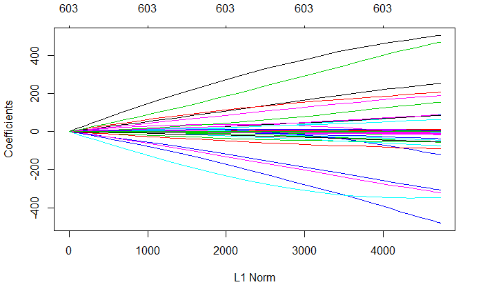

```r
grid = 10^seq(10, -2, length = 100)
ridge.mod <- glmnet (x_train,y_train,alpha =0, lambda =grid)
plot(ridge.mod )
```

Apply cross validation to choose the best tuning parameter such the minimize MSE.

```r
cv.ridge = cv.glmnet(x_train, y_train, alpha = 0, nfolds = 5)
print(cv.ridge)
```

```
$lambda
 [1] 175.054115 167.097636 159.502790 152.253142 145.333002 138.727393 132.422019 126.403233 120.658011
[10] 115.173919 109.939086 104.942185 100.172401  95.619411  91.273361  87.124846  83.164887  79.384915
[19]  75.776748  72.332578  69.044950  65.906751  62.911187  60.051777  57.322331  54.716942  52.229973
[28]  49.856040  47.590006  45.426967  43.362241  41.391360  39.510059  37.714266  36.000094  34.363834
[37]  32.801945  31.311046  29.887911  28.529459  27.232751  25.994981  24.813469  23.685658  22.609108
[46]  21.581490  20.600578  19.664249  18.770479  17.917332  17.102961  16.325605  15.583581  14.875284
[55]  14.199179  13.553804  12.937763  12.349722  11.788408  11.252607  10.741158  10.252956   9.786943
[64]   9.342112   8.917498   8.512184   8.125292   7.755985   7.403464   7.066965   6.745760   6.439155
[73]   6.146486   5.867118   5.600449   5.345900   5.102920   4.870985   4.649591   4.438260   4.236534
[82]   4.043977   3.860172   3.684721   3.517245   3.357381   3.204783   3.059120   2.920079   2.787357
[91]   2.660667   2.539735   2.424301   2.314112   2.208932   2.108533   2.012697

$cvm
 [1] 0.1033658 0.1033302 0.1033321 0.1033342 0.1033364 0.1033388 0.1033414 0.1033165 0.1030802 0.1030715
```

[output cut: 176 more lines]

What is the best tuning parameter ?

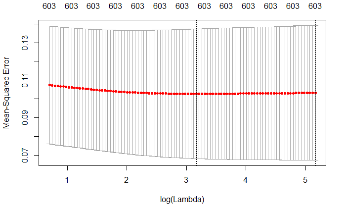

```r
plot(cv.ridge)
```

```r
bestlam_ridge = cv.ridge$lambda.min ;
bestlam_ridge
```

```
[1] 23.68566
```

Judge our model

```r
###  MSE
ridge.pred_test = predict( ridge.mod, s = bestlam_ridge , newx = x_test)
ridge.pred_train = predict( ridge.mod, s = bestlam_ridge , newx = x_train)
MSE_Ridge_train <- mean(( ridge.pred_train -y_train)^2)
MSE_Ridge_test <- mean(( ridge.pred_test -y_test)^2)
data.frame(ridge.pred_train , y_train)
```

|  | X1 | y_train |
| --- | --- | --- |
| 1 | 1.979347 | 1.891357 |
| 2 | 1.922995 | 1.708429 |
| 3 | 1.926574 | 1.856714 |
| 4 | 2.055354 | 2.342786 |
| 5 | 1.915758 | 1.512000 |
| 6 | 2.021248 | 2.165929 |
| 7 | 2.013808 | 2.134643 |
| 8 | 1.987189 | 2.193214 |
| 9 | 2.062238 | 2.397214 |
| 10 | 1.898644 | 1.685143 |

[output cut: 25 more lines]

```r
data.frame(ridge.pred_test , y_test)
```

|  | X1 | y_test |
| --- | --- | --- |
| 1 | 2.0159572 | 1.835500 |
| 2 | 1.9728490 | 2.290143 |
| 3 | 1.9781409 | 2.242071 |
| 4 | 1.9543305 | 1.847500 |
| 5 | 2.0153087 | 1.916786 |
| 6 | 1.9367139 | 1.800786 |
| 7 | 2.0406178 | 2.014929 |
| 8 | 2.0291889 | 1.960571 |
| 9 | 1.9940542 | 2.417143 |
| 10 | 1.9386096 | 1.736357 |

[output cut: 13 more lines]

```r
data.frame(MSE_Ridge_train , MSE_Ridge_test)
```

| MSE_Ridge_train | MSE_Ridge_test |
| --- | --- |
| 0.06678797 | 0.1648006 |

```r
Ridge_bias <- mean((y_test-mean(ridge.pred_test))^2)
Ridge_variance <- mean((ridge.pred_test-mean(ridge.pred_test))^2)
data.frame(Ridge_bias,Ridge_variance,MSE_Ridge_test)
```

| Ridge_bias | Ridge_variance | MSE_Ridge_test |
| --- | --- | --- |
| 0.09999292 | 0.1690677 | 0.1648006 |

```r
# Use all data
out.ridge = glmnet(X, y, alpha = 0)
ridge_coef <- predict(out.ridge ,type="coefficients",s=bestlam_ridge )[,]
tmp_coeffs <- ridge_coef
data.frame(name = tmp_coeffs@Dimnames[[1]][tmp_coeffs@i + 1], coefficient = tmp_coeffs@x)
```

| name | coefficient |
| --- | --- |
| (Intercept) | 2.629784e+03 |
| DV.CurvatureBubbler02_MFC.VALUE | 5.348843e-03 |
| DV.CurvatureBubbler02_PressureControllerPC90.VALUE | -1.520963e-02 |
| DV.CurvatureBubbler08_BathTemp.VALUE | -7.850618e-03 |
| DV.CurvatureBubbler08_MFC.VALUE | 5.048086e-02 |
| DV.CurvatureBubbler08_PressureControllerPC90.VALUE | -2.286080e-02 |
| DV.CurvatureBubbler09_BathTemp.VALUE | -7.852570e-03 |
| DV.CurvatureBubbler09_MFC.VALUE | -2.306418e-03 |
| DV.CurvatureBubbler09_PressureControllerPC90.VALUE | -5.921496e-02 |
| DV.CurvatureButterflyGateVale_position.VALUE | 2.025819e-03 |

[output cut: 594 more lines]

#### Lasso Regression

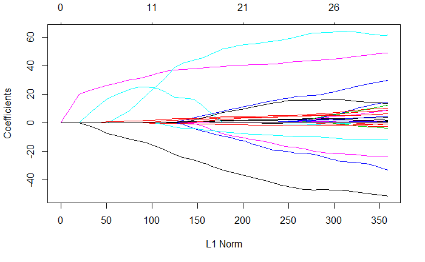

```r
train.lasso <- glmnet(x_train, y_train, alpha = 1)
plot(train.lasso)
```

```r
cv.lasso = cv.glmnet(x_train, y_train, alpha = 1 , nfolds = 5) ;
print(cv.lasso)
```

```
$lambda
 [1] 0.175054115 0.167097636 0.159502790 0.152253142 0.145333002 0.138727393 0.132422019 0.126403233
 [9] 0.120658011 0.115173919 0.109939086 0.104942185 0.100172401 0.095619411 0.091273361 0.087124846
[17] 0.083164887 0.079384915 0.075776748 0.072332578 0.069044950 0.065906751 0.062911187 0.060051777
[25] 0.057322331 0.054716942 0.052229973 0.049856040 0.047590006 0.045426967 0.043362241 0.041391360
[33] 0.039510059 0.037714266 0.036000094 0.034363834 0.032801945 0.031311046 0.029887911 0.028529459
[41] 0.027232751 0.025994981 0.024813469 0.023685658 0.022609108 0.021581490 0.020600578 0.019664249
[49] 0.018770479 0.017917332 0.017102961 0.016325605 0.015583581 0.014875284 0.014199179 0.013553804
[57] 0.012937763 0.012349722 0.011788408 0.011252607 0.010741158 0.010252956 0.009786943 0.009342112
[65] 0.008917498 0.008512184 0.008125292 0.007755985 0.007403464 0.007066965 0.006745760 0.006439155
[73] 0.006146486 0.005867118 0.005600449 0.005345900 0.005102920 0.004870985 0.004649591 0.004438260
[81] 0.004236534 0.004043977 0.003860172

$cvm
 [1] 0.1048688 0.1055429 0.1061374 0.1070979 0.1083199 0.1096691 0.1110230 0.1126016 0.1143756 0.1161383
```

[output cut: 161 more lines]

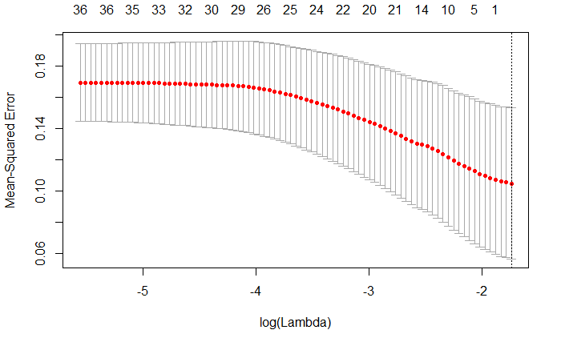

```r
plot(cv.lasso)
```

```r
bestlam_lasso = cv.lasso$lambda.min ;
bestlam_lasso
```

```
[1] 0.1750541
```

```r
lasso.pred_test = predict( train.lasso, s = bestlam_lasso , newx = x_test)
lasso.pred_train = predict( train.lasso, s = bestlam_lasso , newx = x_train)
MSE_lasso_train <- mean(( lasso.pred_train -y_train)^2)
MSE_lasso_test <- mean(( lasso.pred_test -y_test)^2)
data.frame(lasso.pred_train , y_train)
```

|  | X1 | y_train |
| --- | --- | --- |
| 1 | 1.978418 | 1.891357 |
| 2 | 1.978418 | 1.708429 |
| 3 | 1.978418 | 1.856714 |
| 4 | 1.978418 | 2.342786 |
| 5 | 1.978418 | 1.512000 |
| 6 | 1.978418 | 2.165929 |
| 7 | 1.978418 | 2.134643 |
| 8 | 1.978418 | 2.193214 |
| 9 | 1.978418 | 2.397214 |
| 10 | 1.978418 | 1.685143 |

[output cut: 25 more lines]

```r
data.frame(lasso.pred_test , y_test)
```

|  | X1 | y_test |
| --- | --- | --- |
| 1 | 1.978418 | 1.835500 |
| 2 | 1.978418 | 2.290143 |
| 3 | 1.978418 | 2.242071 |
| 4 | 1.978418 | 1.847500 |
| 5 | 1.978418 | 1.916786 |
| 6 | 1.978418 | 1.800786 |
| 7 | 1.978418 | 2.014929 |
| 8 | 1.978418 | 1.960571 |
| 9 | 1.978418 | 2.417143 |
| 10 | 1.978418 | 1.736357 |

[output cut: 13 more lines]

```r
data.frame(MSE_lasso_train , MSE_lasso_test)
```

| MSE_lasso_train | MSE_lasso_test |
| --- | --- |
| 0.1005859 | 0.08151001 |

```r
lasso_bias <- mean((y_test-mean(lasso.pred_test))^2)
lasso_variance <- mean((lasso.pred_test-mean(lasso.pred_test))^2)
data.frame(lasso_bias,lasso_variance,MSE_lasso_test)
```

| lasso_bias | lasso_variance | MSE_lasso_test |
| --- | --- | --- |
| 0.08151001 | 0 | 0.08151001 |

```r
# Use all data
out.lasso = glmnet(X, y, alpha = 1)
lasso_coef <- predict(out.lasso ,type="coefficients",s=bestlam_lasso )[,]

tmp_coeffs <- lasso_coef
data.frame(name = tmp_coeffs@Dimnames[[1]][tmp_coeffs@i + 1], coefficient = tmp_coeffs@x)
```

| name | coefficient |
| --- | --- |
| (Intercept) | 1.980419 |

The result is absolutely useless.

If we insist to get a interpretable model, and willing to sacrifice some variance.  
e.g. we may set the tuning parameter to a little value, say 0.05

```r
bestlam_lasso <- 0.05
```

|  | X1 | y_train |
| --- | --- | --- |
| 1 | 1.980448 | 1.891357 |
| 2 | 1.842580 | 1.708429 |
| 3 | 1.998400 | 1.856714 |
| 4 | 2.126191 | 2.342786 |
| 5 | 1.705040 | 1.512000 |
| 6 | 2.054272 | 2.165929 |
| 7 | 2.021341 | 2.134643 |
| 8 | 2.054411 | 2.193214 |
| 9 | 2.222735 | 2.397214 |
| 10 | 1.697810 | 1.685143 |

[output cut: 25 more lines]

|  | X1 | y_test |
| --- | --- | --- |
| 1 | 1.878800 | 1.835500 |
| 2 | 1.747040 | 2.290143 |
| 3 | 2.002433 | 2.242071 |
| 4 | 1.716380 | 1.847500 |
| 5 | 2.005726 | 1.916786 |
| 6 | 2.181068 | 1.800786 |
| 7 | 1.930815 | 2.014929 |
| 8 | 2.181988 | 1.960571 |
| 9 | 1.957674 | 2.417143 |
| 10 | 1.689366 | 1.736357 |

[output cut: 13 more lines]

| MSE_lasso_train | MSE_lasso_test |
| --- | --- |
| 0.02132737 | 176.3125 |

| lasso_bias | lasso_variance | MSE_lasso_test |
| --- | --- | --- |
| 7.296349 | 166.6484 | 176.3125 |

```r
lasso.pred_test = predict( train.lasso, s = bestlam_lasso , newx = x_test[-18,])
lasso.pred_train = predict( train.lasso, s = bestlam_lasso , newx = x_train)
MSE_lasso_train <- mean(( lasso.pred_train -y_train)^2)
MSE_lasso_test <- mean(( lasso.pred_test -y_test[-18])^2)
data.frame(lasso.pred_train , y_train)
```

|  | X1 | y_train |
| --- | --- | --- |
| 1 | 1.980448 | 1.891357 |
| 2 | 1.842580 | 1.708429 |
| 3 | 1.998400 | 1.856714 |
| 4 | 2.126191 | 2.342786 |
| 5 | 1.705040 | 1.512000 |
| 6 | 2.054272 | 2.165929 |
| 7 | 2.021341 | 2.134643 |
| 8 | 2.054411 | 2.193214 |
| 9 | 2.222735 | 2.397214 |
| 10 | 1.697810 | 1.685143 |

[output cut: 25 more lines]

```r
data.frame(lasso.pred_test , y_test[-18])
```

|  | X1 | y_test..18. |
| --- | --- | --- |
| 1 | 1.878800 | 1.835500 |
| 2 | 1.747040 | 2.290143 |
| 3 | 2.002433 | 2.242071 |
| 4 | 1.716380 | 1.847500 |
| 5 | 2.005726 | 1.916786 |
| 6 | 2.181068 | 1.800786 |
| 7 | 1.930815 | 2.014929 |
| 8 | 2.181988 | 1.960571 |
| 9 | 1.957674 | 2.417143 |
| 10 | 1.689366 | 1.736357 |

[output cut: 12 more lines]

```r
data.frame(MSE_lasso_train , MSE_lasso_test)
```

| MSE_lasso_train | MSE_lasso_test |
| --- | --- |
| 0.02132737 | 0.09042003 |

```r
lasso_bias <- mean((y_test-mean(lasso.pred_test))^2)
lasso_variance <- mean((lasso.pred_test-mean(lasso.pred_test))^2)
data.frame(lasso_bias,lasso_variance,MSE_lasso_test)
```

| lasso_bias | lasso_variance | MSE_lasso_test |
| --- | --- | --- |
| 0.08584467 | 0.0224816 | 0.09042003 |

| name | coefficient |
| --- | --- |
| (Intercept) | 2.377417e+04 |
| DV.H6.Barrier1WSiH403_PC.VALUE | 2.060614e-01 |
| DV.H6.Barrier2WRealTemp_Middle_WaferTemp.VALUE | -5.753741e-02 |
| DV.H6.Barrier3WCenter_Purge_NH3_MFC_51.VALUE | -2.767153e+00 |
| DV.H6.Barrier5SpindleMotor.VALUE | -7.241086e+00 |
| DV.H6.Barrier6WBubbler08_BathTemp.VALUE | 2.328856e+00 |
| DV.H6.Barrier6WBubbler09_BathTemp.VALUE | 1.822710e-15 |
| DV.H6.well2Bubbler08_MFC.VALUE | -8.487344e-01 |
| DV.H6.well2SiH403_PC.VALUE | -1.945512e+00 |
| DV.H6.well5Bubbler02_PressureControllerPC90.VALUE | -1.656461e+00 |

[output cut: 9 more lines]

#### Relaxed Lasso

```r
out.lasso = glmnet(x_test, y_test, alpha = 1)
lasso_coef <- predict(out.lasso ,type="coefficients",s=bestlam_lasso )[,]

tmp_coeffs <- lasso_coef
ttt <- lm(X.PL.WD.STD~. , data=select(train , c((tmp_coeffs@Dimnames[[1]][tmp_coeffs@i + 1])[-1]) , "X.PL.WD.STD" ) )
summary(ttt)
```

```
Call:
lm(formula = X.PL.WD.STD ~ ., data = select(train, c((tmp_coeffs@Dimnames[[1]][tmp_coeffs@i +
    1])[-1]), "X.PL.WD.STD"))

Residuals:
     Min       1Q   Median       3Q      Max
-0.37018 -0.19542 -0.04696  0.14202  0.73341

Coefficients:
                                                        Estimate Std. Error t value Pr(>|t|)
(Intercept)                                            4.922e+04  4.082e+04   1.206   0.2402
DV.H6.Barrier3WPyro_Purge_N2_MFC_46.VALUE             -2.282e+01  5.501e+01  -0.415   0.6821
DV.H6.Barrier5Pyro_Purge_N2_MFC_46.VALUE               1.397e+02  1.252e+02   1.116   0.2759
DV.H6.Barrier5WBubbler08_PressureControllerPC90.VALUE -1.154e+01  2.182e+01  -0.529   0.6021
DV.H6.well2Bubbler08_MFC.VALUE                        -2.974e+00  7.140e+00  -0.417   0.6809
DV.H6.well2SiH403_PC.VALUE                            -6.742e+00  7.236e+00  -0.932   0.3612
DV.H6.well3SpindleMotor.VALUE                         -1.375e+00  2.210e+00  -0.622   0.5398
DV.HT.Barrier1.rampRealTemp_Inner_WaferTemp.VALUE     -1.386e+00  9.778e-01  -1.417   0.1698
DV.Q3.Barrier1Bubbler01_PressureControllerPC90.VALUE  -3.654e+01  3.078e+01  -1.187   0.2473
DV.Q3.Barrier2SiH403_PC.VALUE                          4.122e+00  2.460e+01   0.168   0.8684
DV.Q3.Barrier3Bubbler09_BathTemp.VALUE                -4.296e+01  2.333e+01  -1.841   0.0785 .
DV.Q2.Barrier3SiH403_Mixed                            -1.008e+04  1.437e+04  -0.701   0.4903
---
Signif. codes:  0 '***' 0.001 '**' 0.01 '*' 0.05 '.' 0.1 ' ' 1

Residual standard error: 0.3203 on 23 degrees of freedom
Multiple R-squared:  0.3298,    Adjusted R-squared:  0.009329
F-statistic: 1.029 on 11 and 23 DF,  p-value: 0.4538
```

```r
Least.Squares_predict_train <- predict(ttt, newdata = select(train,-"X.PL.WD.STD"))
Least.Squares_predict_test <- predict(ttt, newdata = select(test,-"X.PL.WD.STD"))
MSE_LS_train <- mean(( Least.Squares_predict_train -y_train)^2)
MSE_LS_test <- mean(( Least.Squares_predict_test -y_test)^2)
data.frame(Least.Squares_predict_train , y_train)
```

|  | Least.Squares_predict_train | y_train |
| --- | --- | --- |
| 1 | 2.171568 | 1.891357 |
| 2 | 1.855501 | 1.708429 |
| 3 | 1.902088 | 1.856714 |
| 4 | 1.969372 | 2.342786 |
| 5 | 1.882185 | 1.512000 |
| 6 | 1.937556 | 2.165929 |
| 7 | 2.027216 | 2.134643 |
| 8 | 1.856420 | 2.193214 |
| 9 | 2.034418 | 2.397214 |
| 10 | 1.837544 | 1.685143 |

[output cut: 25 more lines]

```r
data.frame(Least.Squares_predict_test , y_test)
```

|  | Least.Squares_predict_test | y_test |
| --- | --- | --- |
| 1 | 2.102032 | 1.835500 |
| 2 | 2.100646 | 2.290143 |
| 3 | 2.061452 | 2.242071 |
| 4 | 2.301755 | 1.847500 |
| 5 | 1.938293 | 1.916786 |
| 6 | 1.870477 | 1.800786 |
| 7 | 1.993144 | 2.014929 |
| 8 | 2.121612 | 1.960571 |
| 9 | 2.003739 | 2.417143 |
| 10 | 1.661959 | 1.736357 |

[output cut: 13 more lines]

```r
data.frame(MSE_LS_train , MSE_LS_test)
```

| MSE_LS_train | MSE_LS_test |
| --- | --- |
| 0.0674086 | 0.08714545 |

```r
LS_bias <- mean((y_test-mean(Least.Squares_predict_test))^2)
LS_variance <- mean((Least.Squares_predict_test-mean(Least.Squares_predict_test))^2)
data.frame(LS_bias,LS_variance,MSE_LS_test)
```

| LS_bias | LS_variance | MSE_LS_test |
| --- | --- | --- |
| 0.08164504 | 0.06450791 | 0.08714545 |

Limitations of Lasso 1. In the p>n case, lasso selects at most n variables. 2. If there is a group of variables among which the pairwise correlations  
are very high, then the lasso tends to select only one variable from the  
group and does not care which one is selected.

#### Elastic net

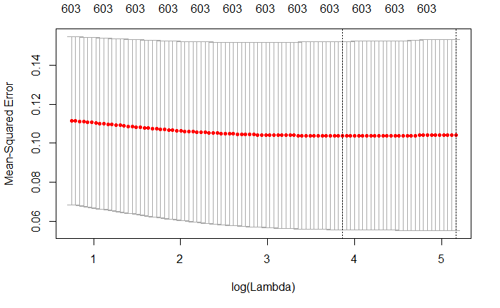

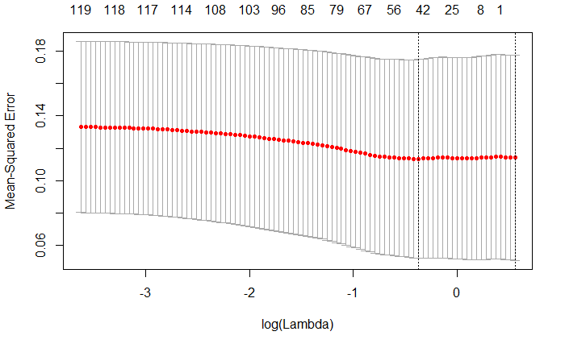

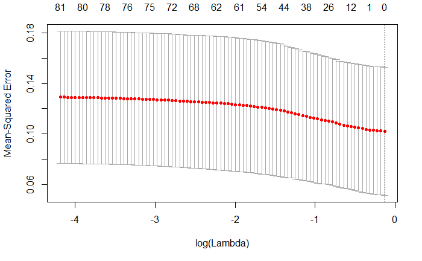

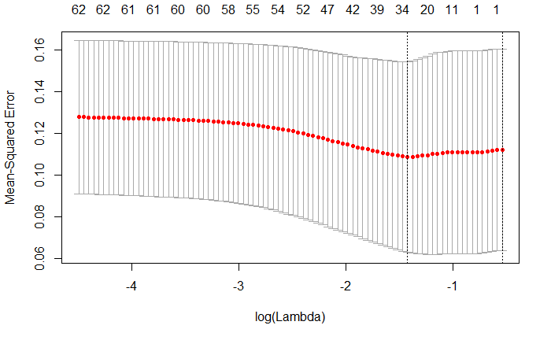

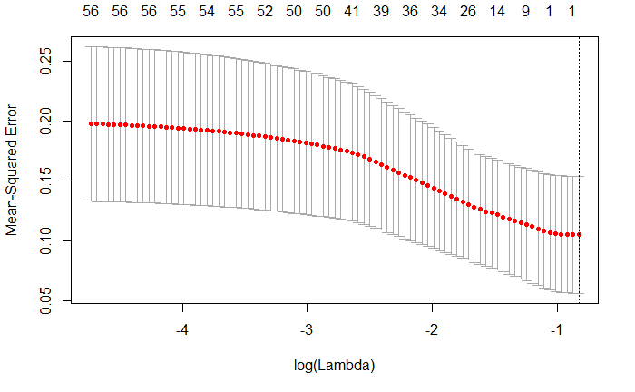

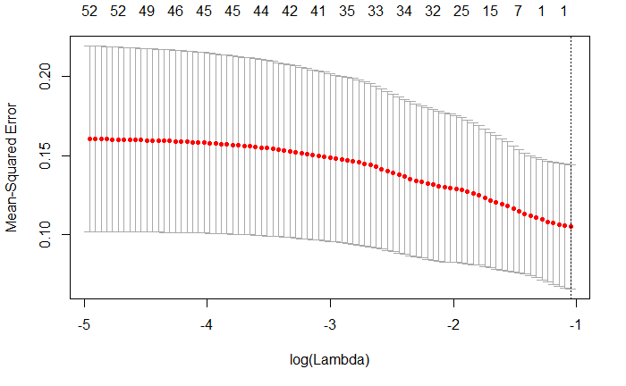

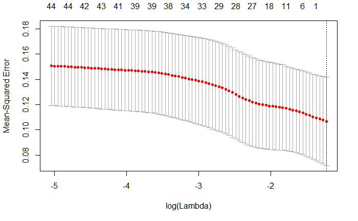

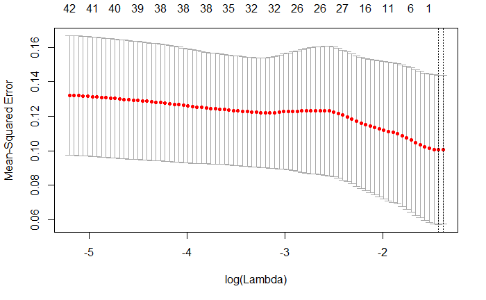

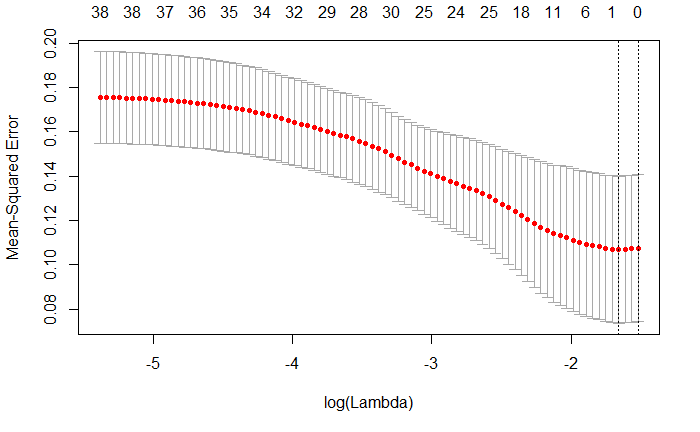

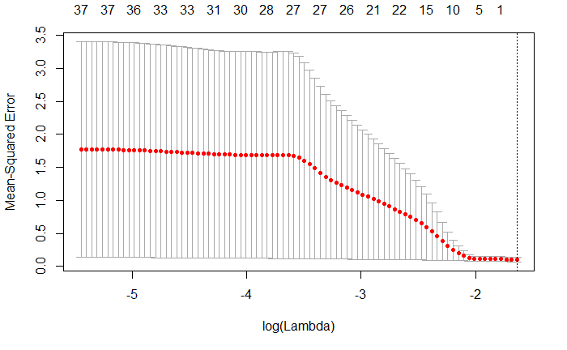

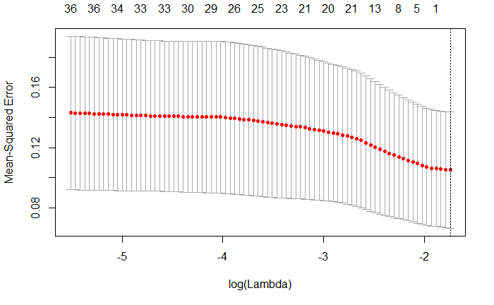

```r
fit_list <- list()
for (i in 0:10) {
  temp_cv <- cv.glmnet(x_train, y_train, type.measure="mse",
                       alpha=i/10 , nfolds=5)

  fit_list[[i+1]] <- temp_cv
  #assign(paste("fit", i, sep=""), temp_cv)
  rm(temp_cv)
}
for (i in 0:10){
  print(plot(fit_list[[i+1]]))
}
```

Again, judge our models.

```r
MSE_list <- list()
for (i in 0:10){
  temp_yhat <- predict(fit_list[[i+1]] , s = fit_list[[i+1]]$lambda.min , newx=x_test)

  MSE_list[[i+1]] <- mean((y_test-temp_yhat)^2)
}
c(MSE_list)
```

```
[[1]]
[1] 0.1036651

[[2]]
[1] 0.2490845

[[3]]
[1] 0.08151001

[[4]]
[1] 0.1916274

[[5]]
[1] 0.08151001

[[6]]
[1] 0.08151001

[[7]]
[1] 0.08151001

[[8]]
[1] 0.08345897

[[9]]
[1] 0.08799756

[[10]]
[1] 0.08151001

[[11]]
[1] 0.08151001
```

For alpha=0.1

```r
out.lasso = glmnet(X, y, alpha = 0.1, intercept = T)
EN_coef <- predict(out.lasso ,type="coefficients",s= fit_list[[2]]$lambda.min)[,]

tmp_coeffs <- EN_coef
data.frame(name = tmp_coeffs@Dimnames[[1]][tmp_coeffs@i + 1], coefficient = tmp_coeffs@x)
```

| name | coefficient |
| --- | --- |
| (Intercept) | 8.099525e+03 |
| DV.H6.Barrier1RealTemp_Middle_WaferTemp.VALUE | -3.948884e-04 |
| DV.H6.Barrier1WRealTemp_Middle_WaferTemp.VALUE | -1.834413e-03 |
| DV.H6.Barrier2RealTemp_Middle_WaferTemp.VALUE | -7.579177e-03 |
| DV.H6.Barrier2WRealTemp_Middle_WaferTemp.VALUE | -8.646281e-03 |
| DV.H6.Barrier3RealTemp_Middle_WaferTemp.VALUE | -3.791494e-03 |
| DV.H6.Barrier3WCenter_Purge_NH3_MFC_51.VALUE | -1.287218e-01 |
| DV.H6.Barrier5SpindleMotor.VALUE | -2.076272e+00 |
| DV.H6.Barrier5WCenter_Purge_N2_MFC_49.VALUE | -9.395537e-01 |
| DV.H6.Barrier6WBubbler08_BathTemp.VALUE | 2.616098e-01 |

[output cut: 18 more lines]

Ideas : * Grouped variables * Query data from all MOCVD machine